# Lab 06

The format of this lab follows the same format as the previous ones. Your goal is to predict the value of the third column (which will be missing on the test set) using the techniques we have learned so far.

*Additionally*: For this lab, fit at least one model using the matrix formulation we saw today with `lm.fit`. I also encourage you to figure out a way to use the latitude and longitude variables, though this is not a requirement.

# Set up

```r
library(readr)
library(dplyr)
library(ggplot2)
library(viridis)
housing <- read_csv("~/files/ml_data_full/ca_pa_house_price.csv")
```

Notice that the test set here is not a random subset of the data but has very different properties that than the other variables.

# Lab 06

## Training and Testing Split

Hopefully you noticed that the data are split into training and testing in an interesting way. Namely, the test set exists only for houses in Pennsylvania and the training/validation set is only from California. (You don’t need the **ggmap** function to see this, but replacing `qplot` with `qmplot` gives a nice map of the data):

```
Using zoom = 6...
```

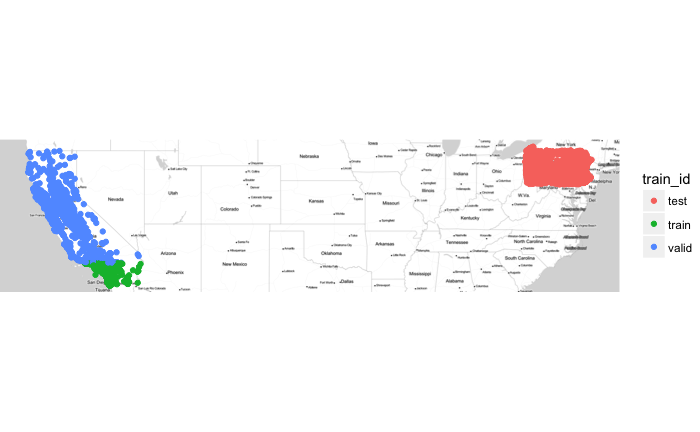

```r
library(ggmap)
qmplot(longitude, latitude, data = housing, color = train_id)
```

Of course, our model will perform very differently in these two places if we use longitude and latitude. Also, the scale of the housing prices is different in California and Pennsylvania. Therefore I have used the gain metric instead of the RMSE. To illustrate the gain, I’ve loaded in the full dataset (with non-missing responses on the test set). Lets fit a simple model to the data to illustrate:

```r
model <- lm(median_house_value ~ median_rooms + owners,
            data = housing,
            subset = (train_id == "train"))
housing$price_pred <- predict(model, newdata = housing)
```

The RMSE is very different on the test set because housing prices are significantly lower in Pennslyvania compared to California:

```r
sqrt(tapply((housing$price_pred - housing$median_house_value)^2, housing$train_id, mean))
```

```
    test    train    valid
323169.8 178157.0 215368.4
```

## Gain Metric

One way to account for this difference in our data is to use a different metric to test how good our predictions are. Here, I’ll order all of the predictions from lowest to highest, and plot the cumulative proportion of the response variable that has been captured by a given proportion of the data. I have loaded the full dataset (with the full test set) to illustrate the effect here:

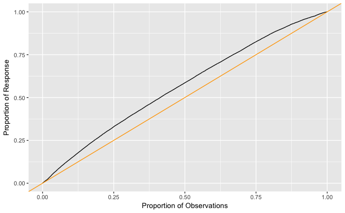

```r
prd <- housing$price_pred[housing$train_id == "train"]
val <- housing$median_house_value[housing$train_id == "train"]
val <- val[order(prd, decreasing = TRUE)]
qplot(seq_along(val) / length(val), cumsum(val) / sum(val), geom = "line") +
  geom_abline(intercept = 0, slope = 1, color = "orange") +
  xlab("Proportion of Observations") + ylab("Proportion of Response")
```

```r
gain <- sum(cumsum(val) / sum(val) / length(val))
gain
```

```
[1] 0.5658807
```

## Using Matrices

As I asked you to do, here we will fit a model using raw matrices. I will use the median rooms and owners variables as well as the latitude and longitude variables.

```r
X <- as.matrix(select(housing, median_rooms, owners,
                      latitude, longitude))
X <- cbind(1, X)
X_train <- X[housing$train_id == "train",]
X_valid <- X[housing$train_id == "valid",]
X_test  <- X[housing$train_id == "test",]
y_train <- housing$median_house_value[housing$train_id == "train"]
y_valid <- housing$median_house_value[housing$train_id == "valid"]
y_test <- housing$median_house_value[housing$train_id == "test"]
beta <- solve(t(X_train) %*% X_train, t(X_train) %*% y_train)
beta
```

```
                      [,1]
             -1.714659e+07
median_rooms  6.642856e+04
owners       -4.966501e+02
latitude     -1.195206e+05
longitude    -1.809646e+05
```

```r
housing$price_pred <- X %*% beta
```

The gain here is not very good because the latitude and longitude variable terms do not translate to Pennsylvania:

```r
prd <- housing$price_pred[housing$train_id == "test"]
val <- housing$median_house_value[housing$train_id == "test"]
val <- val[order(prd, decreasing = TRUE)]
gain <- sum(cumsum(val) / sum(val) / length(val))
gain
```

```
[1] 0.4464065
```

Of course, the RMSE is much worse:

```r
sqrt(tapply((housing$price_pred - housing$median_house_value)^2, housing$train_id, mean))
```

```
     test     train     valid
7835841.2  156618.5  271223.5
```

We can fix this by only applying the terms that do not include spatial information:

```r
housing$price_pred <- X[,1:3] %*% beta[1:3]
```

The gain is not virtually the same as before:

```r
prd <- housing$price_pred[housing$train_id == "test"]
val <- housing$median_house_value[housing$train_id == "test"]
val <- val[order(prd, decreasing = TRUE)]
gain <- sum(cumsum(val) / sum(val) / length(val))
gain
```

```
[1] 0.5716043
```

## Fitting to residuals

Another way to incorporate the spatial component into the model is to fit a spatial only model to the training data and compute the residuals:

```r
model <- lm(median_house_value ~ poly(longitude, latitude, degree = 3),
            data = housing,
            subset = (train_id == "train"))
housing$residual <- housing$median_house_value - predict(model, newdata = housing)
```

We then fit a non-spatial model to the residuals and use this model to predict the housing values in Pennsylvania:

```r
model <- lm(residual ~ median_rooms + owners,
            data = housing,
            subset = (train_id == "train"))
housing$price_pred <- predict(model, newdata = housing)
prd <- housing$price_pred[housing$train_id == "test"]
val <- housing$median_house_value[housing$train_id == "test"]
val <- val[order(prd, decreasing = TRUE)]
gain <- sum(cumsum(val) / sum(val) / length(val))
gain
```

```
[1] 0.5715457
```

Again, this did not improve much but shows another way of achieving a very similar gain.

# Submission

The code below assumes that you have added a prediction named `price_pred` to every row of the dataset.

```r
submit <- select(housing, obs_id, price_pred)
write_csv(submit, "class06_submit.csv")
```

Now, upload this file (ends with “.Rmd”), the HTML output (ends with “.nb.html” or “.html”), and the csv file to GitHub.